# How to Become a Data Analyst

郭耀仁 Yao-Jen Kuo

## Agenda

- TL; DR
- IMHO
- Answer Like a Data Analyst
- Books and Coming Soon
- Q&A

## TL; DR

> To answer the question “How to become a data analyst” is kind of tricky for beginner. It somehow requires a bit of analytical thinking to hit the ball. In short, the question and the answer itself forms a recursive situation. If we answer this question the old way, we might trapped ourselves into a embarrasing dilemma. It is best if we could answer the question with the mindset of a data analyst.

# About me

## Could that data be any tidier?

[figure not shown]

Source: https://www.pinkvilla.com

## I teach data science

- 台大資工系統訓練班資深講師（授課時數 2000+ 小時）
- 資策會資料工程師養成班（Python 網路爬蟲、R 程式設計）
- 中華電信學院（Python 資料科學、機器學習）
- 2019 華南銀行 Python 資料科學講師
- 2017 玉山銀行 Python 資料科學講師

## I blog on Medium

- Follow me on https://medium.com/@tonykuoyj
- Or follow my publications
  - https://medium.com/datainpoint
  - https://medium.com/pyradise

## And of course, collecting them into books

- [輕鬆學習R語言：從基礎到應用，掌握資料科學的關鍵能力](https://www.tenlong.com.tw/products/9789865022433?list_name=srh)
- [進擊的資料科學：Python與R的應用實作](https://www.tenlong.com.tw/products/9789865021825?list_name=srh)

## I run marathon

PR 2:43:12 at 2019 Seoul Marathon

## I previously worked as a …

- Senior Data Analyst at Coupang
- Senior Analytical Consultant at SAS
- Management Associate at CTBC
- Research Intern at McKinsey & Company

## I studied at

- M.B.A., National Taiwan University
- B.A., National Taiwan University

# IMHO

## Data Science is definitely NOT something new

[figure not shown]

Source: https://youtu.be/Z4gjQ8_Gvu4

[figure not shown]

Source: https://youtu.be/Z4gjQ8_Gvu4

## Data Science is the combination of

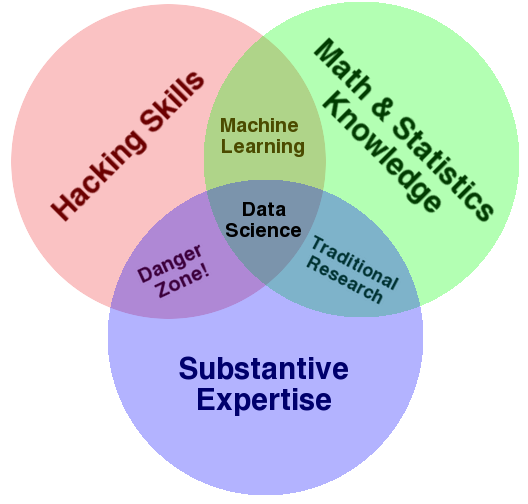

Source: http://drewconway.com/zia/2013/3/26/the-data-science-venn-diagram

## Both statistics and computer science are evergreen trees

> The earliest writing on statistics was found in a 9th-century book entitled Manuscript on Deciphering Cryptographic Messages.

Source: https://en.wikipedia.org/wiki/Statistics#History

> Wilhelm Schickard designed and constructed the first working mechanical calculator in 1623.

Source: https://en.wikipedia.org/wiki/Computer_science#History

## And it is nothing new that we know statisticians can code

- R
- SAS
- Stata
- Minitab
- SPSS

## [Hadley Wickham](http://hadley.nz/) is actually a statistician who can code EXTREMELY well

## Let’s talk about how “I” become a data analyst

## My first encounter of data science can be traced back to 2007, in my junior year

[figure not shown]

## I then met R in grduate school around 2009

[figure not shown]

## Marketing and financial specilists combined SQL and Excel for a long time

[figure not shown]

## In 2014, I started my data science journey as a analytical consultant at SAS

Project scope including:

- Environment configuration
- ETL
- Visualization
- Modeling
- Training

## At that time, the go-to choice of data science is R, which is a strong competitor of SAS

## That’s when I started learning R on Coursera

[Data Science Specialization](https://www.coursera.org/specializations/jhu-data-science)

## And also a couple of other courses, including the famous “Machine Learning”

- [Machine Learning](https://www.coursera.org/learn/machine-learning)
- [Statistics with R Specialization](https://www.coursera.org/specializations/statistics)
- [Applied Data Science with Python Specialization](https://www.coursera.org/specializations/data-science-python)

## Met [DataCamp](https://www.datacamp.com/courses/tech:python?tap_a=5644-dce66f&tap_s=194899-1fb421) in Mine Çetinkaya-Rundel’s course

[figure not shown]

## Started doing tons of interactive exercises and projects on [DataCamp](https://www.datacamp.com/courses/tech:python?tap_a=5644-dce66f&tap_s=194899-1fb421)

## Meanwhile, I took plenty of courses at CSIE Training Program that is not relevant to Data Science

https://train.csie.ntu.edu.tw/train/

## Got a chance to lecture R at CSIE Training Program

## Met the founder of [DataCamp](https://www.datacamp.com/courses/tech:python?tap_a=5644-dce66f&tap_s=194899-1fb421) while running 2016 Boston Marathon

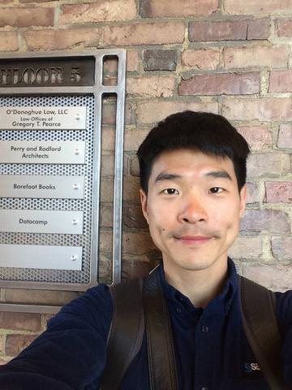

## Btw, the finish line of 2016 Boston Marathon

[figure not shown]

[figure not shown]

## The 2017 iTHelp Ironman, Big Data Section

https://ithelp.ithome.com.tw/2017ironman/8th_winner

## IMHO: we could become a data analyst via

- Learning from different resources
- Doing data projects
- Sharing what we’ve learned
- Hunting for a relevant job, ITERATIVELY

## Another IMHO: skillsets of a data analyst

- Command line / Markup languages
- Spreadsheet
- SQL / Python / R
- Applied statistics
- Applied machine learning

[figure not shown]

# Answer Like a Data Analyst

## What’s wrong with IMHO?

## IMHO is actually the opposite of “Data Driven” decision making

## Data Analyst is all about being “Data Driven”

> Data Analyst makes decisions interpreted from data, not one’s instincts or experience.

## So how do we answer this question like a Data Analyst?

## First thing first: problem decomposition

- The definition
- The how

## What is a Data Analyst, anyway?

https://www.quora.com/What-is-a-data-analyst-1

[figure not shown]

Source: https://twitter.com/cdixon/status/428914681911070720

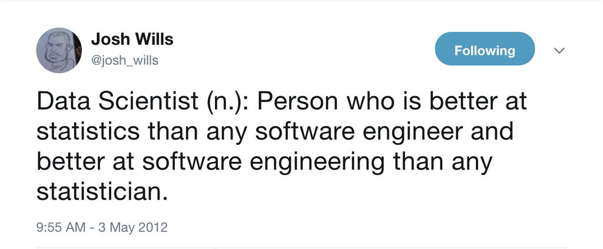

Source: https://twitter.com/josh_wills/status/198093512149958656

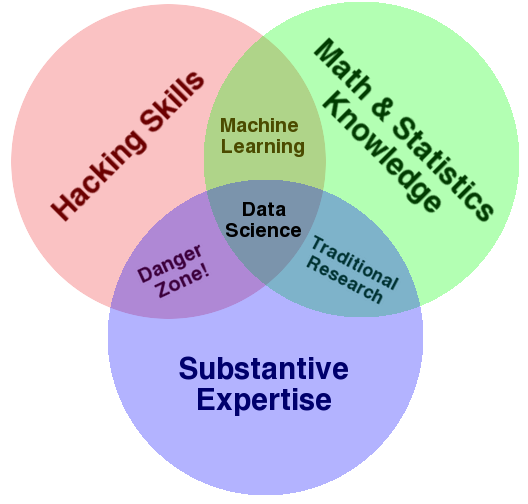

Source: http://drewconway.com/zia/2013/3/26/the-data-science-venn-diagram

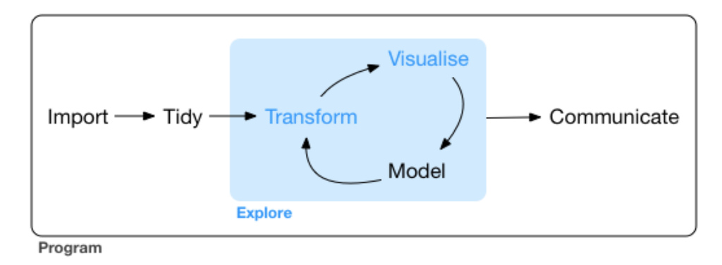

Source: https://r4ds.had.co.nz/explore-intro.html

## After quick surveys, we might come out a brief definition

> A data analyst is someone who uses programming/software handling data-relevant tasks including importing, cleaning, exploration, modeling and communication in aid of making a data-driven decision.

## Then comes the “HOW” part

## Well, this probably simplified too much…

$\text{Statistics} \cap \text{Computer Science} \cap \text{Applications} = \text{Data Science}$

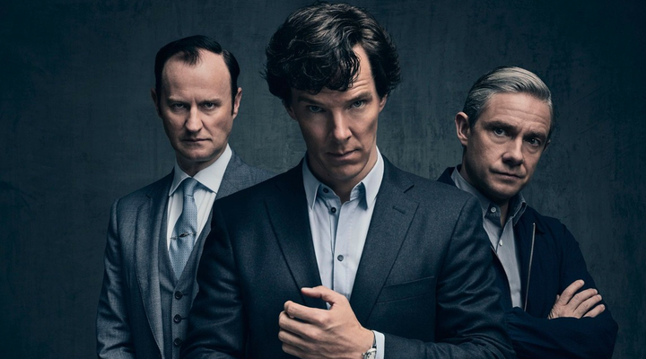

Source: https://www.bbc.co.uk/programmes/b018ttws

## The demand

- [Glassdoor](https://www.glassdoor.com/)
- [LinkedIn](https://www.linkedin.com/)
- [Indeed](https://www.indeed.com/)
- [Stackoverflow Jobs](https://stackoverflow.com/jobs)
- [104 人力銀行](https://www.104.com.tw/)
- [CakeResume](https://www.cakeresume.com/)
- …etc.

## The supply

- [2017 Kaggle ML & DS Survey](https://www.kaggle.com/kaggle/kaggle-survey-2017)
- [2018 Kaggle ML & DS Survey](https://www.kaggle.com/kaggle/kaggle-survey-2018)
- And…let’s wait for the 2019 version

## We may come out with a portrait of data analyst by matching both demand and supply

[figure not shown]

Source: https://www.themarketingdistillery.com/

## Destination confirmed, then the journey plan

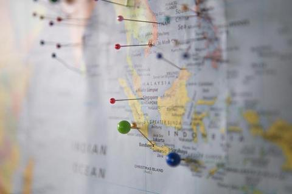

Source: https://unsplash.com/photos/TrhLCn1abMU

## 180 days of preparation is reasonable for most people

- 90-120 days if you are extraordinary hard-working
- 270-360 days if you are kind of loose(like me)

## Start job hunting after 2/3 of your preparation

# Books and Coming Soon

## I’ve written 2 books currently

- [輕鬆學習R語言：從基礎到應用，掌握資料科學的關鍵能力](https://www.tenlong.com.tw/products/9789865022433?list_name=srh)
- [進擊的資料科學：Python與R的應用實作](https://www.tenlong.com.tw/products/9789865021825?list_name=srh)

## Why did I start writing/blogging?

## I realized it is probably “my thing” after participating 2017 iThelp Ironman

https://ithelp.ithome.com.tw/2017ironman/8th_winner

## Of course, free copies are available online:

- [輕鬆學習 R 語言](https://www.datainpoint.com/r-essentials/)
- [進擊的資料科學](https://www.datainpoint.com/data-science-in-action/)

## That’s a way to salute to admiring data scientists

- [Hadley Wickham](http://hadley.nz/)
- [Jake VanderPlas](https://jakevdp.github.io/pages/about.html)

## Coming soon…

- Writing my third book
- An introductory course on [Hahow](https://hahow.in)

## I will write a book on:「資料分析師的學習筆記 | Python 視覺化與機器學習」

Estimated publish date: end of 2nd quarter, 2020.

## An introductory course “How to Become a Data Analyst” will be published on [Hahow](https://hahow.in) before Feb, 2020

## We will try our best answering the question like a Data Analyst!

Kindly fill the survey and collect a 20% off discount

[figure not shown]